# Analyzing Student Video Engagement: How Length Impacts Drop-Off

## Executive Summary

Students engage **significantly more** with **shorter instructional videos** than with lengthy ones.

In an analysis of **41,768 cleaned and aggregated video viewing sessions** (originally 66,064 before data preparation), Visualizations use the cleaned, aggregated dataset (~41.8k rows) derived from 66k+ raw session records after timestamp/units normalization and removal of impossible drop-off values. We observed a clear **inverse relationship** between **video length** and **student completion rates**. In simple terms, **the longer the video, the more students tend to drop off before finishing it**.

Brief videos (those under about 10 minutes) maintain far higher viewer retention on average, whereas longer lectures (30+ minutes) experience steep fall-off, often losing the majority of students partway through.

This finding suggests that, to maximize engagement, educators should:

- Keep videos concise, focusing each on a single concept or learning objective, or
- Break longer lectures into shorter, well-structured segments to sustain attention.

# Metrics used in this report

### Completion rate (interval-based, %): Average percentage of the video watched.

### Drop-off (quartile score, 0–4): Average number of quartiles viewers reached; lower = earlier exits.

### Plays vs Loads: Plays are starts; Loads are player impressions. LOAD/PLAY reflects conversion, not depth of viewing.

### The following report details these engagement patterns, drop-off trends, and viewer behavior insights, concluding with actionable recommendations for designing more effective instructional videos that sustain student attention and improve learning outcomes.

# The Big Picture – Shorter Videos, Higher Completion

When we look across the dataset, one pattern stands out immediately:

> **The shorter the video, the higher the completion rate.**

Students are far more likely to finish short clips than long lectures.

- **Videos under 5 minutes** achieve the **highest engagement**, with viewers watching **about half or more** of the entire video on average.
- **Mid-length videos** between **15–30 minutes** perform moderately, averaging **~39–42% completion**.
- **Hour-long lectures**, however, struggle to hold attention the **average completion rate drops to just ~18%**.

## These figures aren’t isolated anomalies. Each category represents **thousands of videos** for example, the *sub-5-minute group* alone contains **over 9,000 videos**.

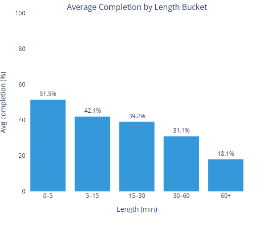

### Figure: Average Completion by Length Bucket

> The downward trend illustrates how attention naturally declines as videos get longer.

In the visualization above, each bar represents the **average completion percentage** for videos within a specific length range.  
The **downward slope** tells a straightforward story:

- **Shorter videos have higher completion**
- **Longer videos have lower completion**

### Supporting Research and Context

These findings mirror what prior studies in educational media have long suggested:

> “Student engagement peaks in videos around **6 minutes or shorter**, and even in formal lecture settings, keeping videos under **15 minutes** yields significantly higher retention.”

### Key Takeaway

Short, concise videos outperform longer lectures across every engagement metric.  
By **segmenting long lessons into focused, topic-based clips**, educators can significantly boost completion rates and improve overall learning effectiveness.

## Transition to Deeper Insights

The completion trends revealed in the earlier visuals show what happens as videos get longer engagement declines sharply. But to truly understand why this happens, it’s important to look deeper into how the underlying metrics behave together.

That’s where the correlation analysis comes in. By examining how completion, drop-off, and minutes, we uncover the mechanics of engagement showing that it’s not driven by a single factor, but by how consistently students stay engaged once they start watching.

## **How Do Engagement Metrics Relate to Each Other?**

The heatmap below visualizes the **correlation between key engagement indicators** including completion rate, drop-off, video length, and viewing time to uncover how these metrics move together.

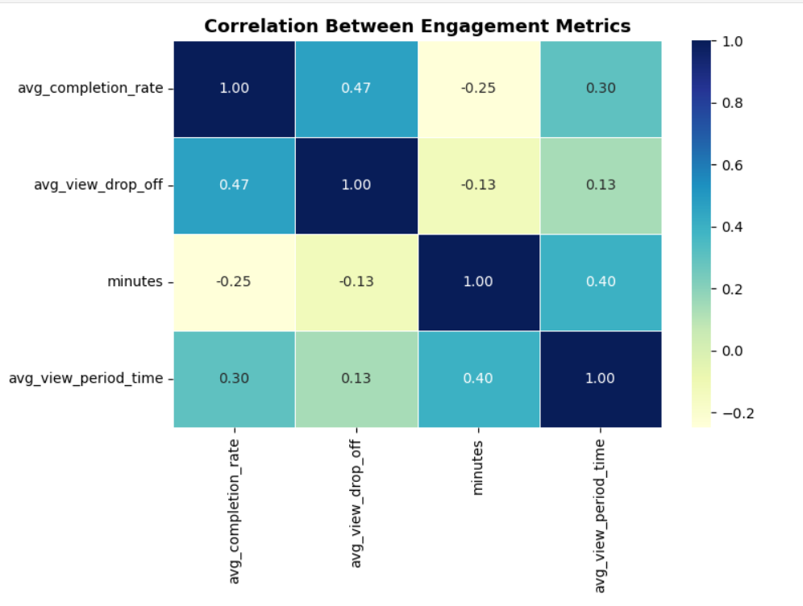

### **Figure: Correlation Between Engagement Metrics**

> **Interpretation:**  
> The color intensity indicates the **strength and direction** of relationships (blue for strong, yellow for weak).
> - **Completion Rate vs. Drop-Off (r = 0.47):** A moderate positive relationship, suggesting that when completion rates are high, drop-off rates (as measured cumulatively across intervals) also appear higher often due to high overall engagement activity in those videos.
> - **Completion Rate vs. Video Length (r = -0.25):** A mild **negative correlation** longer videos tend to have lower completion percentages.
> - **Video Length vs. Drop-Off (r = -0.13):** A **slightly negative association**, meaning as **video length increases**, **drop-off also worsens** students disengage earlier in longer videos. This aligns with the broader pattern that **attention declines as duration extends**.
> - **Video Length vs. Viewing Time (r = 0.40):** Expectedly positive as videos grow longer, the total watch time also increases, though not proportionally.
> - **Completion Rate vs. Average View Period (r = 0.30):** Students who complete more of a video also tend to watch for longer absolute durations.

### **Key Insights**

- No pair shows an extremely strong correlation (≥ 0.7), indicating that **each engagement metric captures a different behavioral dimension** completion, attention span, or duration.
- The **inverse pattern** between *video length* and *completion* reaffirms the earlier finding that **longer content discourages sustained attention**.
- The **negative trend between video length and drop-off** further confirms that **longer videos experience higher early abandonment**, meaning students tend to stop watching midway as length increases.
- The **moderate tie between viewing time and length** shows that while long videos do accumulate more total watch time, **students rarely reach the end** of them.

### **Takeaway**

This correlation analysis reinforces a central insight:

> **Video length alone cannot predict engagement it interacts with how students allocate their time and attention.**

Shorter, well-structured videos encourage **higher completion** and **more consistent viewing behavior**, while longer ones risk **fragmented attention** and **early disengagement** despite higher total watch time.

### Transition to the Next Layer of Insight

While the correlation heatmap revealed how engagement metrics move together, it doesn’t show when attention actually starts to fade. To uncover that, we turn to a granular, time-based perspective analyzing how quickly students begin to drop off as videos grow longer.

## **When exactly do students begin to disengage?**

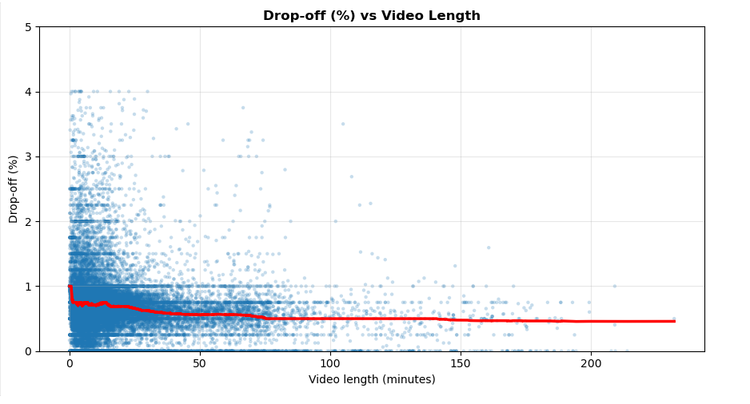

### Figure: Drop-Off (%) vs. Video Length

> **Interpretation:**  
> This visualization highlights how **viewer drop-off intensifies as videos grow longer**.
> - Each blue point marks a video’s observed drop-off rate.
> - The red curve summarizes average behavior.
> - The steep initial decline and flattening tail indicate that most students **lose interest early**, especially in longer lectures.

### Key Observations

In other words, the longer the video runs, the more students “check out” before it finishes a pattern that repeats across nearly all categories.

### Takeaway

--

### Transition to the Next Insight

Having seen how engagement steadily declines as videos grow longer,  
the next step is to pinpoint **where attention is maximized** the balance point between **video length** and **viewer persistence**.

To uncover this, we compare two key engagement metrics side by side:  
**completion rate** (how much is watched) and **drop-off ratio** (how quickly viewers leave).

This combined view reveals the **“engagement sweet spot”** the duration range where students stay most attentive before attention begins to sharply decline.

# Engagement Sweet Spot by Video Length

Having examined overall viewing patterns, we now explore **how engagement varies with video length** identifying where learners stay most attentive versus where attention fades.

The chart below contrasts two core engagement metrics:

- **Completion Rate (green line):** How much of each video is watched on average.
- **Drop-Off Ratio (red line):** How quickly viewers disengage as content progresses.

Together, these reveal how **video duration directly impacts learner persistence and attention**.

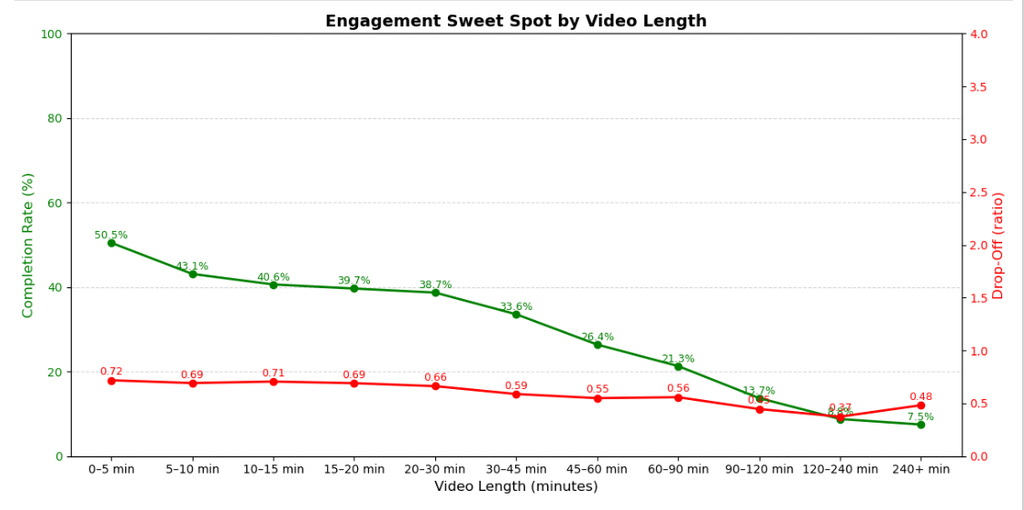

### Key Insight

##### Different meanings of "drop-off"

In the heatmap, “drop-off” means how far students reached before leaving.

So if students watched more (high completion), the drop-off point also moves later, it's a positive relationship.

Both completion and drop-off increase together when engagement is high.

In the sweet spot chart, “drop-off ratio” means how many students left early.

##### Different analysis levels

The heatmap looks at correlation across all videos individually.

The sweet spot groups videos by length buckets (0–5 min, 5–10 min, etc.) and shows how averages change with duration.

### Transition to the Next Layer of Analysis

Now that we’ve identified the **optimal engagement window (5–15 minutes)**,  
the next question is: *how common are videos that actually fall into this range?*

To answer that, we look beyond averages and trends to examine the **full landscape of engagement**.  
The **density map** below visualizes how thousands of videos distribute across completion and duration  
revealing where engagement naturally concentrates and where it fades away.

## Engagement Density (Completion vs. Video Length)

### Where most videos actually fall?

After seeing how completion and drop-off vary with duration, it’s helpful to examine **where most videos actually fall** on that spectrum.  
The **engagement density map** below visualizes the overall distribution of student behavior across thousands of videos.

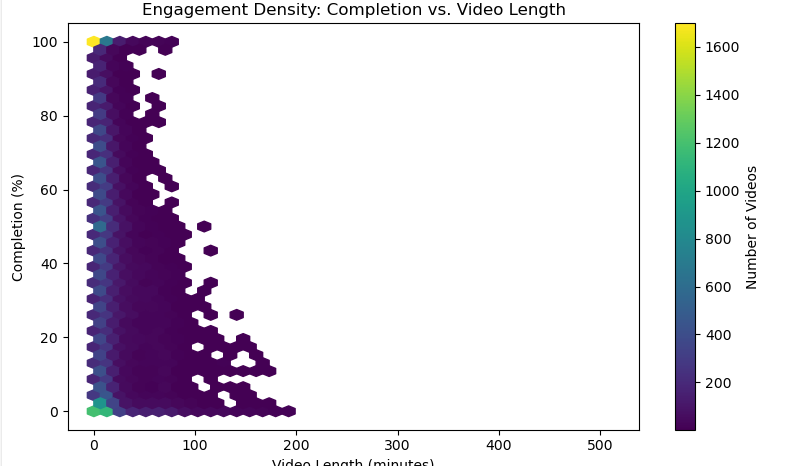

### Figure: Engagement Density — Completion vs. Video Length

> Together, these density patterns paint a clear picture of how attention behaves across different video lengths.

### Key Observations

In other words, most videos live in one of two worlds:

1. **Short and engaging**, or
2. **Long and largely abandoned**.

### Insight

> The density gradient strongly reinforces the **inverse relationship** between **video length** and **viewer completion**.  
> As videos grow longer, the cluster of engagement shifts steadily downward from high completion toward near-zero retention.

This pattern visualizes what earlier charts suggested numerically:  
an unmistakable **“attention decay effect.”**  
Each additional minute of content reduces the likelihood of full viewing, emphasizing the importance of concise, targeted design.

### Summary of Key Visual Insights

[output not shown]

# Why Do Students Drop Off?

The data tells us **when** students stop watching but the more important question is **why**.  
To uncover that, we have to look beyond the metrics and think about **what’s happening in the learner’s experience**.

### Universal Trend Across Courses

Across thousands of videos, the same pattern holds true:

> **No matter the subject or instructor, engagement declines as runtime increases.**

There are rare exceptions — for example, an **exam review session** that kept viewers hooked until the end, likely because of its **immediate importance**.  
But these are outliers. In general, **long videos underperform**, while **shorter, focused segments** consistently maintain attention more effectively.

## The Critical First Few Minutes

If there’s one universal rule, it’s this:

> **The first few minutes make or break engagement.**

Nearly every student hits *Play* but what happens next determines how long they’ll stay.

- **Attention starts at its peak** and **drops rapidly** within the opening minutes.
- This creates a **brief but powerful opportunity** for instructors to capture interest and set expectations.
- A **clear, engaging, and relevant introduction** can hold attention, while a **slow or unfocused start** often triggers early disengagement — sometimes before the first concept is even introduced.

### Observed Engagement Pattern

Our analysis revealed a consistent pattern:

> **Engagement is strongest at the start and gradually declines as time goes on —

the longer the video, the steeper the drop.**

By the **halfway mark of a 60-minute lecture**, only a small fraction of students remain.  
In contrast, a **6-minute mini-lecture** often retains most viewers through to the end.

### Instructional Design Insight

Educators don’t just need **shorter videos** they need **stronger beginnings**.  
Start with:

- A **compelling question** or real-world scenario.
- **Clear goals** so learners know what to expect.
- **Visual or tonal variety** to sustain engagement throughout.

> Short videos grab attention; **strong openings sustain it**.  
> Together, they create the foundation for **effective, high-retention instructional design**.

# Recommendations

Overall, the analysis confirms that **video length is one of the strongest predictors of engagement**:

- **Shorter videos** achieve **higher completion and retention**.
- **Longer videos** lose most of their audience well before halfway.

Armed with these insights into **when and why** learners disengage, educators can apply the following strategies:

### Keep It Short and Focused

Attention naturally fades with time. The simplest way to sustain it is to **keep videos concise** — ideally **under 10 minutes**, and rarely beyond **15 minutes**.

If a topic truly requires more time, **split it into smaller, standalone segments** with clear titles or objectives.  
This modular design helps students **rewatch, review, and digest content** at their own pace.

### Start Strong (Hook Viewers Early)

The **first few minutes are make-or-break**. That’s when curiosity is highest and when disengagement begins if the video doesn’t deliver quickly.

Lead with **key takeaways**, **real-world relevance**, or a **thought-provoking question**.  
That strong start ensures that even those who don’t finish still walk away with the most important learning.

### Re-Engage Midway

For videos longer than **10–20 minutes**, introduce small **attention resets**:

- Add an interactive **poll, question, or recap**.
- Switch the **visual format**
- Offer a **brief summary checkpoint** before moving to the next concept.

These moments **break monotony**, **refresh attention**, and **encourage continued viewing**.

### Make Long Videos Easier to Navigate

Sometimes, long videos are unavoidable. When that’s the case, **help learners find what they need**:

- Add **timestamps, chapters, or section markers**.
- Verbally **guide transitions** (“Next, we’ll look at…”).

These small cues support **non-linear learning**, allowing students to **jump to key sections** instead of dropping off entirely.  
Even if they don’t watch everything, they stay engaged longer.

# Conclusion

The analysis makes one finding clear:

> **Shorter videos drive stronger engagement and deeper learning.**

To sustain focus, educators should **keep content concise**, **start strong**, and **design for attention** using **interactive moments** and **clear navigation** when longer videos are necessary.

In short:

> **Brevity isn’t just efficient it’s essential for engagement.**

### When videos are **purposeful**, **focused**, and **well-structured**, students stay connected longer and **learn more effectively**.

### Designing with attention in mind transforms **passive watching into active, meaningful learning**.

# Appendix – Engagement Summary Tables

## Table A1 – Average Completion by Video Length

*(From: “The Big Picture – Shorter Videos, Higher Completion”)*

[output not shown]

*(From: “When Exactly Do Students Begin to Disengage?”)*

## Table A3 – Completion vs. Drop-Off Relationship

*(From: “Engagement Sweet Spot by Video Length”)*

[output not shown]

## Table A4 – Engagement Density Patterns

*(From: “Engagement Density – Completion vs. Video Length”)*

[output not shown]

## Overall Insight

> This validates the **micro-learning design principle** —  
> short, focused videos sustain attention and maximize educational impact.